# Nature-based climate resilience through shoreline transformation

Andre de Souza de Lima $^1$; Tyler Miesse $^1$; Daniel Cardona $^1$; Celso Ferreira $^1$; Ali Shahabi $^2$; Navid Tahvildari $^2$

$^1$ Department of Civil, Environmental and Infrastructure Engineering, George Mason University, Fairfax, VA

$^2$ Department of Civil and Environmental Engineering, Old Dominion University, Norfolk, VA

[figure not shown]

## Introduction

Global climate change has led to many adverse impacts including changing weather patterns and an increase in the severity and frequency of extreme weather events. Traditional hard engineering solutions for coastal protection, such as seawalls and bulkheads, are becoming inadequate as they do not have the capacity to keep pace with the accelerating impacts of climate change. In response, there is growing interest in Natural and Nature-Based Features (NNBF), which offer innovative and adaptive approaches to coastal protection. NNBFs, such as salt marshes or living shorelines, have demonstrated potential for mitigating wave energy, reducing flood risks, and enhancing coastal resilience. However, the effectiveness of these features can vary based on their physical attributes and the specific environmental conditions in which they are implemented. The inconsistent performance of NNBFs has posed challenges for their widespread adoption, partly due to uncertainties in their efficacy and barriers in public policy.

This research focuses on evaluating the performance of NNBFs in attenuating waves through innovative field-scale prototypes and the natural environment. Here we aim to deepen our understanding of how these interventions can contribute to enhancing coastal resilience.

```python
root = pl.Path('C:/Users/decar/OneDrive_George_Mason_University/VASG_prj/Data')

def datenum_to_datetime(datenum):
    return temp
def get_data(fnames, root, file_type = 'before'):
    return data
def plottable_data(data, *, file_type, x_axis = 'not shared'):
    return lines
def add_area(region, name, major, minor = 'None'):
    return line
def updater(fig, xaxis = 'shared'):
    return fig
def plot_sorter(f_name, file_type = 'before'):
    return af
def add_data_to_plot(plot, line, file_type='before'):
    return plot
```

## Project Site Location: Whittaker Creek Canal

The Whittaker Creek Canal project site is man-made canal located in the Middle Peninsula Chesapeake Bay Planning Access Authority’s (MPCBPAA) Captain Sinclair's Recreation Area (CSRA), in Gloucester County, Virginia. The CRSA has historically been used as a research site for shoreline protection projects, due to its vulnerability to sea level rise driven coastal hazards. The CRSA's Whittaker Creek Canal provides a protected location against coastal hazards typical in the area, thus offering a viable setting for controlled experimentation.

[figure not shown]

Credits: Flood Hazards Research Lab Archives, 2024.

### Nature-based Feature Construction

This project in partnership with Biogenic Solutions Consulting, LLC (BSC), Old Dominion University (ODU), and George Mason University (GMU) showcased an innovative design to simultaneously address:

- The dredging needs of a small creek, including property access by boat,
- Shoreline erosion along the adjacent shorelines,
- Living shoreline vegetative production, and
- Existing building rehabilitation (in this case, Whittaker Creek boat ramp).

This initiative involved combining an innovative application of locally dredged materials placed into several geotextile containment tubes (Geotubes™) at the shoreline, prefabricated concrete oyster reef structures, and native salt marsh plants that were transplanted from nearby wetland areas.

[figure not shown]

Cross section diagrams show the canal's physical properties before (a) and after (b) the construction of NNBFs. The diagrams highlight the configuration of NNBFs in the canal, each NNBF's dimensions, and installation methods.

Credits: Biogenic Solutions Consulting, LLC, 2024

After the construction and placement of the oyster reefs and Geotubes™, the result is a protected shoreline along the east, north, and west banks of the Canal. Each bank of the canal provides a different combination of NNBF's; for instance, the west bank offers a combination of oyster reefs and Geotubes™, while the east bank only offers Geotubes™. The north bank is similar to the west bank, in terms of NNBFs provides, but the north bank has an additional line of oyster reef on its eastern half. The varying combinations of NNBFs along the different banks of the canal was to test how hard and soft defenses work together to reduce wave energy.

[figure not shown]

Figure on left shows a closer look at the North bank at low tide, highlighting the prefabricated concrete reefs and Geotube; and figure on the right shows prefabricated concrete buttress reef structures to anchor the geotextile

Credits: Flood Hazards Research Lab Archives, 2024

### Field Experiment Design

At the Whittaker Creek Canal project site, we conducted two field experiments to evaluate the effectiveness of NNBFs at attenuating boat wakes, which are practical emulators of wind waves and storm surge events. One field experiment was conducted before the construction of the NNBFs at the canal, while the other was done after. During the field experiments we would run the same boat down the canal at varying speeds and weights to produce a diverse set of wakes. The varying set of wakes allowed us to simulate different controlled coastal hazard conditions, and observe the response of the NNBFs.

See table and video below to further visualize the experiment design.

| Boat Run | Boat Speed | Speed Range (MPH) | Boat Weight Type | Boat Weight (lbs) |
| --- | --- | --- | --- | --- |
| 1 | Slow | 3 - 5 | Light | 2,360 |
| 2 | Medium | 7 - 9 | Light | 2,360 |
| 3 | Fast | 13 - 17 | Light | 2,360 |
| 4 | Slow | 3 - 5 | Light | 2,360 |
| 5 | Medium | 7 - 9 | Light | 2,360 |
| 6 | Fast | 13 - 17 | Light | 2,360 |
| 7 | Slow | 3 - 5 | Light | 2,360 |
| 8 | Medium | 7 - 9 | Light | 2,360 |
| 9 | Fast | 13 - 17 | Light | 2,360 |
| 10 | Slow | 3 - 5 | Heavy | 2,760 |
| 11 | Medium | 7 - 9 | Heavy | 2,760 |
| 12 | Fast | 13 - 17 | Heavy | 2,760 |
| 13 | Slow | 3 - 5 | Heavy | 2,760 |
| 14 | Medium | 7 - 9 | Heavy | 2,760 |
| 15 | Fast | 13 - 17 | Heavy | 2,760 |
| 16 | Slow | 3 - 5 | Heavy | 2,760 |
| 17 | Medium | 7 - 9 | Heavy | 2,760 |
| 18 | Fast | 13 - 17 | Heavy | 2,760 |

Table details each boat run, indicating the speeds categorized as slow, medium, and fast, as well as the weights associated with light and heavy boat types.

[video not shown]

Video shows typical boat trial run at the canal

Credits: Flood Hazards Research Lab Archives, 2024

To compare the results of the two experiments conducted, one before and after the construction of the NNBFs, we deployed RBR solo D wave loggers to record significant wave height data prior to each field experiment. This wave data, combined with the field experiments, enabled us to clearly observe the impacts of the NNBFs on wave energy.

[figure not shown]

Team of researchers from GMU and ODU deploying wave sensors at Whittaker Creek Canal.

Credits: Lathan Goumas, Virginia Sea Grant.

See aerial maps below detailing the location and affiliated NNBF of each wave logger.

```python
sensors_map
```

[interactive chart not shown]

*Location of RBR solo D Wave Loggers*

### Results

```python
fig.show()
```

[output not shown]

```python
file = pd.read_excel(root / 'boat_runs_with_PWH.xlsx')
```

The figure below illustrates that peak wave heights were consistently higher before the implementation of NNBFs, highlighting the significant impact of these interventions on reducing wave energy. Each point on the graph represents a different run of the boat. Stars indicate heavy loading, while circles represent light loading. The colors signify the boat's speed during each run.

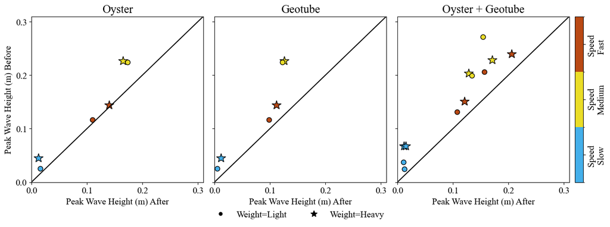

```python
plt.show()
```

This figure illustrates the percent decrease in peak wave height observed in trials conducted before and after the construction of NNBFs. Similar to the previous figure, the colors indicate different boat speeds, while dotted lines represent trials with heavily loaded boats and solid lines indicate trials with lightly loaded boats. The data reveal a significant difference between the effects of a single NNBF and multiple NNBFs.

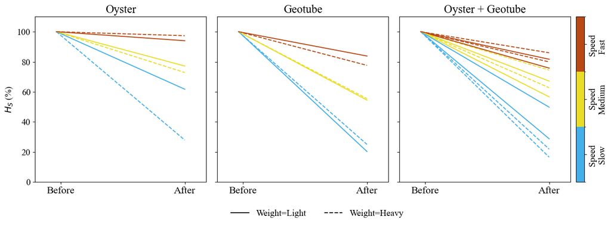

```python
plt.show()
```

### Conclusion

Overall, this study found that these innovative NNBFs significantly reduced wave heights in the Whittaker Creek Canal. Boat speed had a greater impact on wave height than vessel weight, but both factors are important. Most notably, combining different NNBFs, like oyster reefs and Geotubes™, improved wave reduction effectiveness, especially at low boat speeds, making them highly effective under low intensity or daily conditions.